# Analyzing Fairness: Race, Recidivism, and the COMPAS Algorithm

Elisabeth Nesmith, Eunice Kim, Emma Kornberg, Amrita Acharya, Dianne Caravela

3/8/2022

# Data

```python
## load in data
## In machine learning tasks, specifically with supervised learning, you have features and labels.
## The features are the descriptive attributes (they are defined as X), and the label (y) is what you're attempting to predict or forecast

X, y = fetch_compas()
print(f'There are {X.shape[0]} entries and {X.shape[1]} features')
```

```
## There are 6167 entries and 10 features
```

```python
X.head()
```

```
##                            sex  ...                   c_charge_desc
## id sex  race                    ...
## 1  Male Other             Male  ...    Aggravated Assault w/Firearm
## 3  Male African-American  Male  ...  Felony Battery w/Prior Convict
## 4  Male African-American  Male  ...           Possession of Cocaine
## 7  Male Other             Male  ...                         Battery
## 8  Male Caucasian         Male  ...       Possession Burglary Tools
##
## [5 rows x 10 columns]
```

## Filter/configure race

```python
## because our analysis is mainly focusing on how the algorithm treats white and Black people differently, we are
## dropping the rows of data where race != Caucasian or African American
X_new = X[(X.race == "Caucasian") | (X.race == "African-American")]
print(f'There are {X_new.shape[0]} entries and {X_new.shape[1]} features')
```

```
## There are 5273 entries and 10 features
```

```python
X_new.head()
```

```
##                                sex  ...                   c_charge_desc
## id sex    race                      ...
## 3  Male   African-American    Male  ...  Felony Battery w/Prior Convict
## 4  Male   African-American    Male  ...           Possession of Cocaine
## 8  Male   Caucasian           Male  ...       Possession Burglary Tools
## 10 Female Caucasian         Female  ...                         Battery
## 14 Male   Caucasian           Male  ...         Poss 3,4 MDMA (Ecstasy)
##
## [5 rows x 10 columns]
```

```python
## drop unused race categories
# list of categories to be removed
X_new["race"] = X_new["race"].cat.remove_unused_categories()
```

[output not shown]

```python
y_new = y[(y.index.get_level_values(2) == "Caucasian") | (y.index.get_level_values(2) == "African-American")]
y_new.head()
```

```
## id  sex     race
## 3   Male    African-American    Recidivated
## 4   Male    African-American    Recidivated
## 8   Male    Caucasian           Recidivated
## 10  Female  Caucasian              Survived
## 14  Male    Caucasian              Survived
## Name: two_year_recid, dtype: category
## Categories (2, object): ['Survived' < 'Recidivated']
```

```python
# Function for visualising the confusion matrix and other statistics
# https://github.com/DTrimarchi10/confusion_matrix/blob/master/cf_matrix.py

def make_confusion_matrix(cf_matrix, model):
  group_names = ["True Negative","False Positive","False Negative","True Positive"]
  group_counts = ["{0:0.0f}".format(value) for value in
                  cf_matrix.flatten()]
  group_percentages = ["{0:.2%}".format(value) for value in
                      cf_matrix.flatten()/np.sum(cf_matrix)]

  group_labels = ["{}\n".format(value) for value in group_names]
  group_counts = ["{0:0.0f}\n".format(value) for value in cf_matrix.flatten()]
  group_percentages = ["{0:.2%}".format(value) for value in cf_matrix.flatten()/np.sum(cf_matrix)]

  box_labels = [f"{v1}{v2}{v3}".strip() for v1, v2, v3 in zip(group_labels,group_counts,group_percentages)]
  box_labels = np.asarray(box_labels).reshape(cf_matrix.shape[0],cf_matrix.shape[1])


  # add more statistics
  accuracy  = np.trace(cf_matrix) / float(np.sum(cf_matrix))
  precision = cf_matrix[1,1] / sum(cf_matrix[:,1])
  recall    = cf_matrix[1,1] / sum(cf_matrix[1,:])
  f1_score  = 2*precision*recall / (precision + recall)
  stats_text = "\n\nAccuracy={:0.3f}\nPrecision={:0.3f}\nRecall={:0.3f}\nF1 Score={:0.3f}".format(
      accuracy,precision,recall,f1_score)


  categories=["Survived", "Recidivated"]
  sns.heatmap(cf_matrix,annot=box_labels,fmt="",cmap='Purples',xticklabels=categories,yticklabels=categories)

  plt.ylabel('True label')
  plt.xlabel('Predicted label' + stats_text)
  plt.title(f"Confusion matrix and statistics for the {model} model");

## defining function for displaying metrics of training and test data by race
def metrics_per_group(y_test, y_pred):
    # y true per group
    y_test_white = y_test.loc[y_test.index.get_level_values(2) == 1]
    y_test_black = y_test.loc[y_test.index.get_level_values(2) == 0]

    # y_pred per group
    y_pred_white = y_pred[y_test.index.get_level_values(2) == 1]
    y_pred_black = y_pred[y_test.index.get_level_values(2) == 0]

    # metrics
    scores = []
    scores.append(accuracy_score(y_test, y_pred))
    scores.append(recall_score(y_test, y_pred))
    scores.append(precision_score(y_test, y_pred))

    scores.append(accuracy_score(y_test_black, y_pred_black))
    scores.append(recall_score(y_test_black, y_pred_black))
    scores.append(precision_score(y_test_black, y_pred_black))

    scores.append(accuracy_score(y_test_white, y_pred_white))
    scores.append(recall_score(y_test_white, y_pred_white))
    scores.append(precision_score(y_test_white, y_pred_white))

    attribute = ["all"]*3 + ["black"] *3 + ["white"] *3
    metric = ["accuracy", "recall", "precision"] * 3

    # dictionary of lists
    dict = {'race': attribute, 'metrics': metric, 'score': scores}

    df = pd.DataFrame(dict)

    sns.barplot(x = "metrics", y = "score", hue = "race", data = df, palette = ['#dfcd1a', '#9d0677', '#236c48'])
    plt.title("Performance metrics by groups")


def plot_fair_metrics(fair_metrics_mitigated, model):
  cols = ['statistical_parity_difference','equal_opportunity_difference','average_odds_difference','disparate_impact_ratio']
  obj_fairness = [[0,0,0,1]]
  # row for objectives
  fair_metrics = pd.DataFrame(data=obj_fairness, index=['objective'], columns=cols)

  # row for baseline model
  fair_metrics.loc['Baseline'] = [stat_par_diff, eq_opp_diff, avg_odds_diff, disp_impact_ratio]
  # row for mitigated bias
  fair_metrics.loc[model] = fair_metrics_mitigated
  metrics_len = len(cols)
  fig, ax = plt.subplots(figsize=(20,4), ncols=metrics_len, nrows=1)
  plt.subplots_adjust(
      left    =  0.125,
      bottom  =  0.1,
      right   =  0.9,
      top     =  0.9,
      wspace  =  .5,
      hspace  =  1.1
  )
  y_title_margin = 1.2
  plt.suptitle("Fairness metrics", y = 1.09, fontsize=20)
  sns.set(style="dark")
  cols = fair_metrics.columns.values
  obj = fair_metrics.loc['objective']
  size_rect = [0.2,0.2,0.2,0.4]
  rect = [-0.1,-0.1,-0.1,0.8]
  bottom = [-1,-1,-1,0]
  top = [1,1,1,2]
  bound = [[-0.1,0.1],[-0.1,0.1],[-0.1,0.1],[0.8,1.25]]
  for i in range(0,metrics_len):
      plt.subplot(1, metrics_len, i+1)
      ax = sns.barplot(x=fair_metrics.index[1:len(fair_metrics)], y=fair_metrics.iloc[1:len(fair_metrics)][cols[i]])

      for j in range(0,len(fair_metrics)-1):
          a, val = ax.patches[j], fair_metrics.iloc[j+1][cols[i]]
          marg = -0.2 if val < 0 else 0.1
          ax.text(a.get_x()+a.get_width()/5, a.get_y()+a.get_height()+marg, round(val, 3), fontsize=15,color='black')
      plt.ylim(bottom[i], top[i])
      plt.setp(ax.patches, linewidth=0)
      ax.add_patch(patches.Rectangle((-5,rect[i]), 10, size_rect[i], alpha=0.3, facecolor="green", linewidth=1, linestyle='solid'))
      plt.axhline(obj[i], color='black', alpha=0.3)
      plt.title(cols[i])
      ax.set_ylabel('')
      ax.set_xlabel('')
```

```python
X_new.index = pd.MultiIndex.from_arrays(X_new.index.codes, names=X_new.index.names)
y_new.index = pd.MultiIndex.from_arrays(y_new.index.codes, names=y_new.index.names)
# 0 is African American, 2 is Caucasian
```

```python
# set caucasian equal to 1 instead of 2
X_new = X_new.rename(index={2: 1}, level='race')
X_new
```

```
##                   sex  age  ... c_charge_degree                      c_charge_desc
## id   sex race               ...
## 1    0   0       Male   34  ...               F     Felony Battery w/Prior Convict
## 2    0   0       Male   24  ...               F              Possession of Cocaine
## 4    0   1       Male   41  ...               F          Possession Burglary Tools
## 6    1   1     Female   39  ...               M                            Battery
## 7    0   1       Male   27  ...               F            Poss 3,4 MDMA (Ecstasy)
## ...               ...  ...  ...             ...                                ...
## 6165 0   0       Male   30  ...               M  Possess Cannabis/20 Grams Or Less
## 6166 0   0       Male   20  ...               F              Possession of Cocaine
## 6167 0   0       Male   23  ...               F                   Deliver Cannabis
## 6168 0   0       Male   23  ...               F      Leaving the Scene of Accident
## 6170 1   0     Female   33  ...               M      Battery on Law Enforc Officer
##
## [5273 rows x 10 columns]
```

```python
# set target class to 0/1
y_new = pd.Series(y_new.factorize(sort=True)[0], index=y_new.index)
# set caucasian equal to 1 instead of 2
y_new = y_new.rename(index={2: 1}, level='race')
```

```python
y_new
```

```
## id    sex  race
## 1     0    0       1
## 2     0    0       1
## 4     0    1       1
## 6     1    1       0
## 7     0    1       0
##                   ..
## 6165  0    0       1
## 6166  0    0       0
## 6167  0    0       0
## 6168  0    0       0
## 6170  1    0       0
## Length: 5273, dtype: int64
```

# Exploratory Data Analysis

### Descriptions of Average Defendants

```python
# needs interpretation
X_new_index = X_new.rename(columns={"race": "def_race"})
X_new_index = X_new_index.rename(columns={"sex": "def_sex"})
# renaming dataframe columns to avoid the ValueError of variables being a column AND index label (which is ambiguous)

X_new_index.groupby(["def_race"])["age"].median()
```

```
## def_race
## African-American    29.0
## Caucasian           35.0
## Name: age, dtype: float64
```

```python
X_new_index.groupby(["def_race", "sex"]).size()
```

```
## def_race          sex
## African-American  0      2624
##                   1       549
## Caucasian         0      1620
##                   1       480
## dtype: int64
```

```python
X_new_index.groupby(["def_race", "c_charge_degree"]).size()
```

```
## def_race          c_charge_degree
## African-American  F                  2194
##                   M                   979
## Caucasian         F                  1242
##                   M                   858
## dtype: int64
```

```python
X_new_index.groupby(["def_race"])["priors_count"].median()
```

```
## def_race
## African-American    2.0
## Caucasian           1.0
## Name: priors_count, dtype: float64
```

```python
X_new_index.groupby(["def_race"])["juv_fel_count"].median()
```

```
## def_race
## African-American    0.0
## Caucasian           0.0
## Name: juv_fel_count, dtype: float64
```

```python
X_new_index.groupby(["def_race"])["juv_misd_count"].median()
```

```
## def_race
## African-American    0.0
## Caucasian           0.0
## Name: juv_misd_count, dtype: float64
```

The typical Black defendant is 29 years old, male, and has committed two prior crimes. The typical white defendant is 35 years old, male, and has committed one prior crime. The typical defendant for both races does not have any juvenile convictions.

```python
df_viz = X_new.copy()
df_viz['race'] = X_new['race'].replace({1.0: 'Caucasian', 0.0: 'African-American'})
df_viz['two_year_recid'] = y_new.replace({1:'Recidivated', 0: 'Survived'})
df_viz.index = df_viz.index.droplevel('race')

purple = '#9d0677'
green = '#30875c'
orange = '#E7881E'
blue = '#20A4CF'
workshop_palette = [purple, green]
df_viz.head()
```

```
##            sex  age  ...                   c_charge_desc two_year_recid
## id sex               ...
## 1  0      Male   34  ...  Felony Battery w/Prior Convict    Recidivated
## 2  0      Male   24  ...           Possession of Cocaine    Recidivated
## 4  0      Male   41  ...       Possession Burglary Tools    Recidivated
## 6  1    Female   39  ...                         Battery       Survived
## 7  0      Male   27  ...         Poss 3,4 MDMA (Ecstasy)       Survived
##
## [5 rows x 11 columns]
```

### Recidivism Distribution

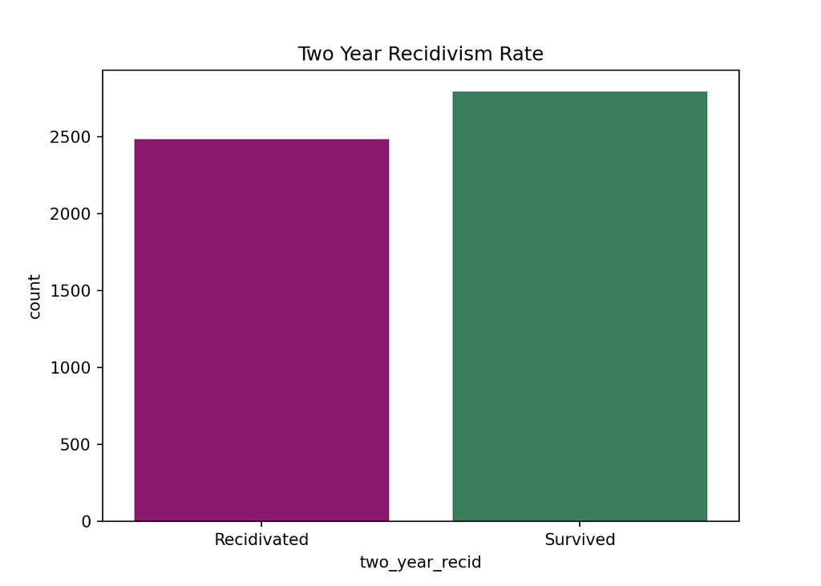

```python
# barplot of recividism
sns.countplot(x='two_year_recid', data=df_viz, palette=workshop_palette)
plt.title('Two Year Recidivism Rate')
```

### Racial Distributions

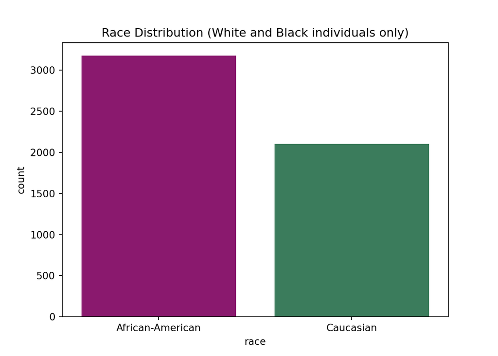

```python
# barplot of race
sns.countplot(x="race", data=df_viz, palette=workshop_palette)
plt.title('Race Distribution (White and Black individuals only)')
plt.show()
```

The dataset we are using contains about 3200 Black defendants and 2100 white defendants. Therefore, there are more Black people represented in the dataset than white people, showing the disproportionate policing and criminalization of Black communities.

#### Age

```python
# age distribution by race - hacking solution for purple dotted line for now
#ax = sns.kdeplot(x="age", hue="race", data=df_viz, palette=workshop_palette);
#kdeline = ax.lines[0]
#mean_black = df_viz.groupby('race').age.median()[0]
#xs = kdeline.get_xdata()
#ys = kdeline.get_ydata()
#height_black = 0.027 # np.interp(mean_black, xs, ys)
#ax.vlines(mean_black, 0, height_black, color=purple, ls=':')

#mean_white = df_viz.groupby('race').age.median()[1]
#height_white = np.interp(mean_white, xs, ys)
#ax.vlines(mean_white, 0, height_white, color=green, ls=':')

#plt.title('Distribution of Age by Race')
```

#### Charge Degree

```python
crosstable=pd.crosstab(df_viz['race'],df_viz['c_charge_degree'])
crosstable
```

```
## c_charge_degree      F    M
## race
## African-American  2194  979
## Caucasian         1242  858
```

```python
props={}
props[('Caucasian','F')]={'facecolor': green, 'edgecolor':'white'}
props[('Caucasian','M')]={'facecolor':green, 'edgecolor':'white'}
props[('African-American','F')]={'facecolor':purple,'edgecolor':'white'}
props[('African-American','M')]={'facecolor':purple,'edgecolor':'white'}
labelizer=lambda k:{('Caucasian','F'):1242,('African-American','F'):2194,('Caucasian','M'):858,('African-American','M'):979}[k]
mosaic(df_viz,['race','c_charge_degree'],labelizer=labelizer,properties=props)
```

```
## (<Figure size 700x500 with 3 Axes>, {('African-American', 'F'): (0.0, 0.0, 0.5987509824290269, 0.6891619802884177), ('African-American', 'M'): (0.0, 0.6924842394246302, 0.5987509824290269, 0.3075157605753696), ('Caucasian', 'F'): (0.6037261068071363, 0.0, 0.39627389319286377, 0.5894636924537257),…
```

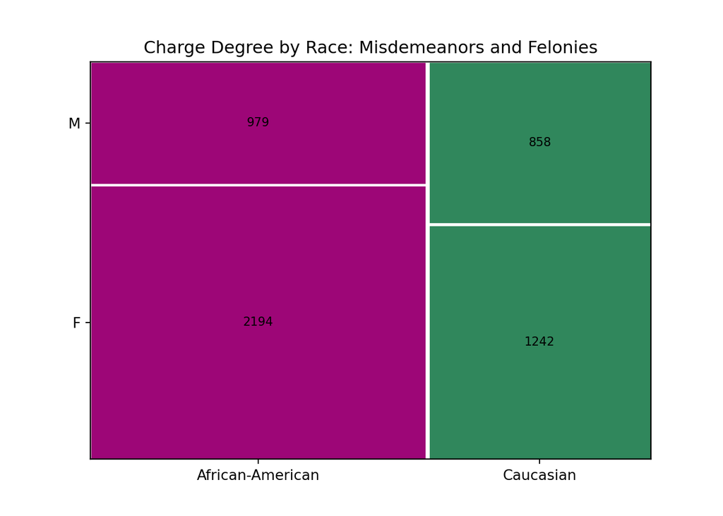

```python
plt.title("Charge Degree by Race: Misdemeanors and Felonies")
plt.rcParams["figure.figsize"]=(7,7)
plt.show()
```

1242 (59.14%) of white defendants were charged with felonies versus 2194 (69.15%) of black defendants. Likewise, a higher percentage of white defendants (40.86%) were charged with a misdemeanor than black defendants (30.85%).

#### Charge Descriptions

```python
from os import path
from PIL import Image
from wordcloud import WordCloud, STOPWORDS, ImageColorGenerator
```

```python
text = " ".join(charge for charge in df_viz.c_charge_desc)
stopwords = set(STOPWORDS)
stopwords.update(["arrest", "case", "charge"])
wordcloud = WordCloud(stopwords=stopwords, background_color="white").generate(text)
```

```python
plt.imshow(wordcloud, interpolation='bilinear')
plt.axis("off")
```

```
## (-0.5, 399.5, 199.5, -0.5)
```

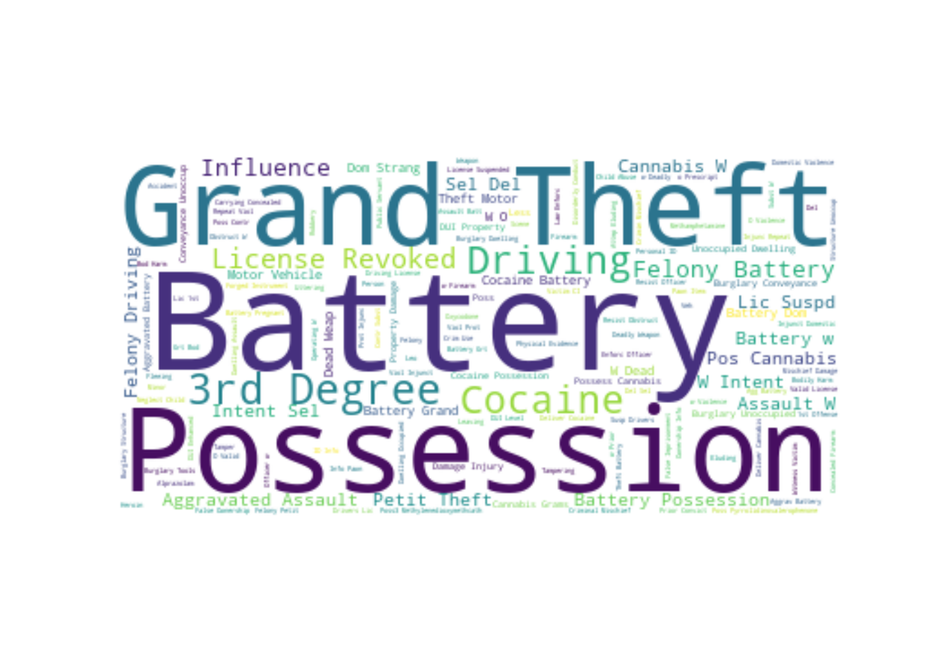

```python
plt.show()
```

#### Recidivism

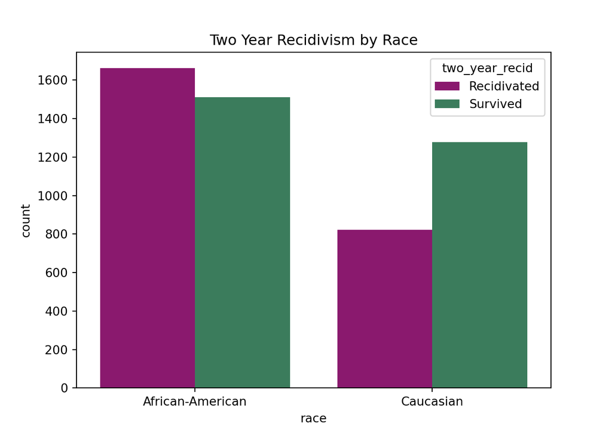

```python
# recidivism by race
by_sex = sns.countplot(x="race", hue="two_year_recid", data=df_viz, palette=workshop_palette)

plt.title('Two Year Recidivism by Race')
plt.show()
```

When we divide the data into Black and white defendants, we can see that Black defendants recidivate more than white defendants and Black defendants are more likely to recidivate than not recidivate. Again, this trend points to disproportionate rates of criminalization of Black people. This increased likelihood of recidivating may be attributed to the systemic racism in policing (e.g., predominantly Black neighborhoods tend to be overpoliced in comparison to predominantly white neighborhoods).

```python
crosstable=pd.crosstab(df_viz['race'],df_viz['two_year_recid'])
crosstable
```

```
## two_year_recid    Recidivated  Survived
## race
## African-American         1661      1512
## Caucasian                 822      1278
```

```python
props={}
props[('Caucasian','Recidivated')]={'facecolor':green, 'edgecolor':'white'}
props[('Caucasian','Survived')]={'facecolor':green, 'edgecolor':'white'}
props[('African-American','Recidivated')]={'facecolor':purple,'edgecolor':'white'}
props[('African-American','Survived')]=        {'facecolor':purple,'edgecolor':'white'}
labelizer=lambda k:{('Caucasian','Recidivated'):822,('African-American','Recidivated'):1661,('Caucasian','Survived'):1278,('African-American','Survived'):1512}[k]
mosaic(df_viz,['race','two_year_recid'],labelizer=labelizer,properties=props)
```

```
## (<Figure size 700x700 with 3 Axes>, {('African-American', 'Recidivated'): (0.0, 0.0, 0.5987509824290269, 0.5217402229986607), ('African-American', 'Survived'): (0.0, 0.5250624821348734, 0.5987509824290269, 0.47493751786512656), ('Caucasian', 'Recidivated'): (0.6037261068071363, 0.0, 0.39627389319…
```

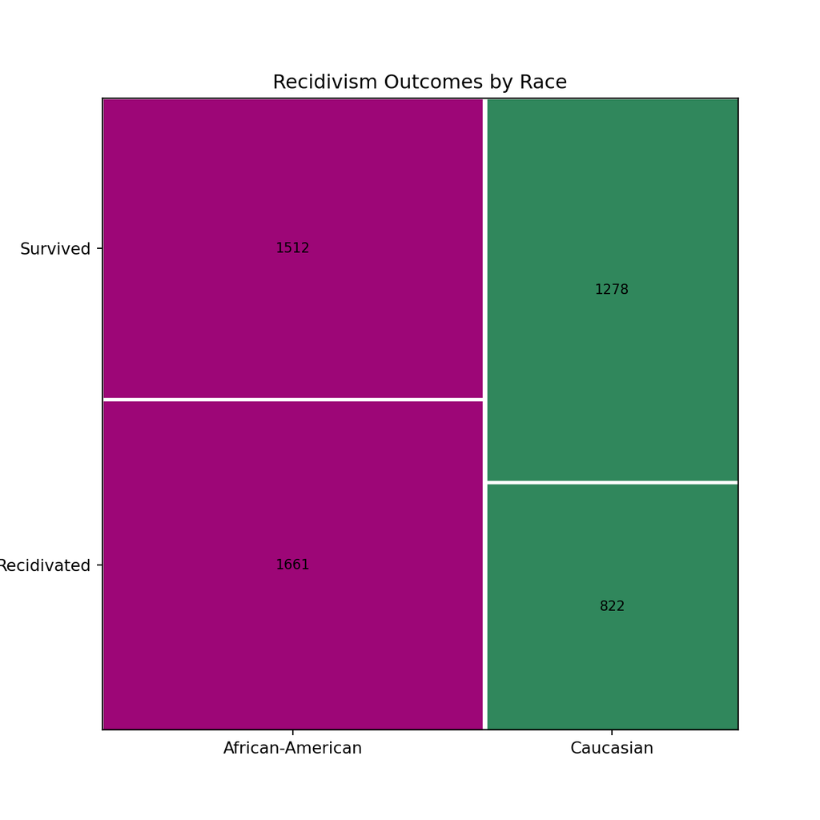

```python
plt.title("Recidivism Outcomes by Race")
plt.rcParams["figure.figsize"]=(7,7)
plt.show()
```

A higher percentage of white defendants (60.86%) than black defendants (47.65%) did not commit another crime within two years. This means that 39.14% of white defendants did recidivate within two years compared to 52.35% of black defendants.

#### Prior Charges

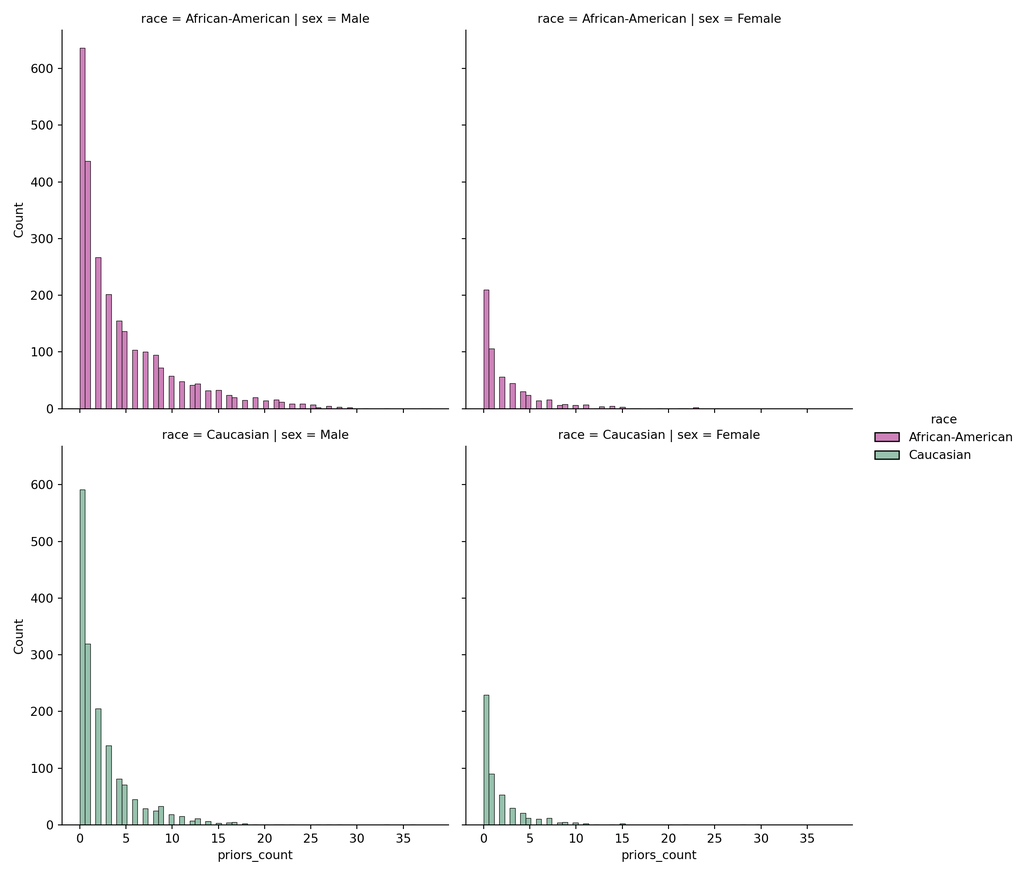

```python
priors_by_race = sns.displot(x="priors_count", row = "race", col = "sex", hue ="race", data=df_viz, palette=workshop_palette)

plt.show()
```

In the above plot, we can see that Black defendants, particularly men, are more likely to have a greater count of prior charges than white defendants. This again likely reflects the over-policing of Black people and communities. Additionally, we can see that male defendants have a higher number of prior charges than do female defendants. This is worth noting as ProPublica found that there is discrepancy in COMPAS risk assessment algorithm’s prediction between sexes. When the recidivsim predictions are compared with the true recividism outcomes, female defendants have a notable false positive rate that predicts their recidivism risk as higher than their true outcomes (ProPublica). Though we do not know for sure which information goes into the COMPAS algorithm, it is likely that a defendant with prior charges will be coded as a having a higher risk of recidivism. Thus, by looking at the racial discrepancies in prior charges we can already see potential bias in the algorithm.

# Baseline Metrics

```python
X_train, X_test, y_train, y_test = train_test_split(X_new, y_new, random_state=1234567)

# one-hoy encode the categorical features
data_preproc = make_column_transformer(
        (OneHotEncoder(sparse=False, handle_unknown='ignore'), X_train.dtypes == 'category'))

X_train = pd.DataFrame(data_preproc.fit_transform(X_train), index=X_train.index)
X_test = pd.DataFrame(data_preproc.transform(X_test), index=X_test.index)

# to save the information for the column names
pd.get_dummies(X_new).head()
```

```
##              age  ...  c_charge_desc_arrest case no charge
## id sex race       ...
## 1  0   0      34  ...                                    0
## 2  0   0      24  ...                                    0
## 4  0   1      41  ...                                    0
## 6  1   1      39  ...                                    0
## 7  0   1      27  ...                                    0
##
## [5 rows x 403 columns]
```

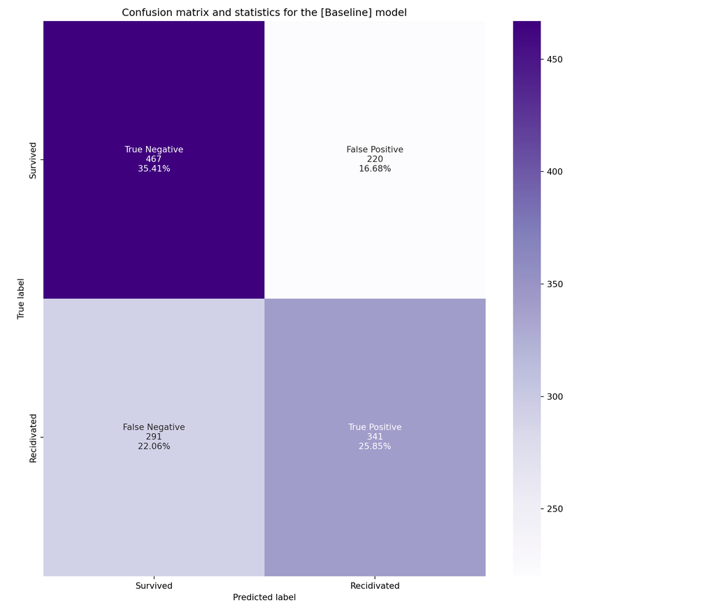

```python
##Look at 2nd column of matrix for precision
##2nd row of matrix for recall
cf_matrix = confusion_matrix(y_test, y_pred)
make_confusion_matrix(cf_matrix, "[Baseline]")
plt.show()
```

The highest percentage in this confusion matrix is for true negatives, defendants who the model predicted to not recidivate and actually did not, at 35.41%. The number of true positives, defendants who the model predicted to recidivate and actually recidivated, is slightly lower at 25.85%. The percentages of false negatives and false positives, which represent incorrect model predictions, are somewhat high for this baseline model. This indicates that the model might need bias mitigation or improvements in accuracy.

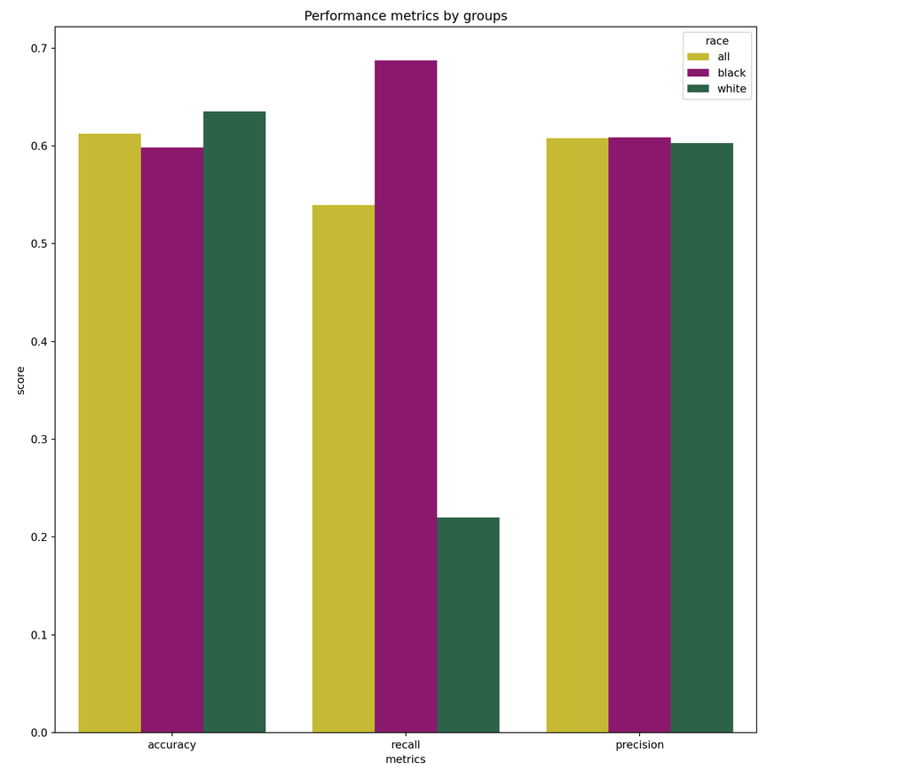

```python
metrics_per_group(y_test, y_pred)
plt.show()
```

This graphs shows three different metrics of model quality and how they differ by race. Accuracy is calculated by summing the total number of true positives and true negatives and dividing by the total number of predictions:

$$\frac{TP + TN}{TP + FP + TN + FN}$$

Accuracy, as the name suggests, quantifies how accurately the model makes predictions. Looking at the graph, we can see that accuracy is fairly similar for Black, white, and all defendants, but the model is slightly less accurate in the case of Black defendants. The model makes accurate predictions for all defendants about 61% of the time, for Black defendants about 59% of the time, and for white defendants about 63% of the time.

The value of recall represents the proportion of actual positives which were predicted correctly. In other words, recall is the number of people who were predicted to recidivate and did recidivate out of the total number of people actually recidivated:

$$\frac{TP}{TP + FN}$$

In the case of our baseline mode, recall is highest for Black defendants at nearly 0.7, while recall for white defendants is much lower at just above 0.2. The model correctly identifies defendants who recidivate about 54% of the time, Black defendants who recidivate about 70% of the time, and white defendants who recidivate about 20% of the time. This means that the model frequently predicts white defendants to not recidivate (the more favorable outcome) when they actually do. This points to potential bias in the model, as the recall score for white defendants is so much lower than that for Black defendants.

Slightly different from recall, precision is the proportion of predicted positives which were actually correct. Precision is therefore the number of people who were predicted to recidivate and did recidivate out of the total number of people who were predicted to recidivate:

$$\frac{TP}{TP + FP}$$

We can see that precision is very similar across groups, all approximately 0.6. This means that the model’s predictions of a defendant, either Black or white, who recidivates are accurate about 60% of the time.

## Group Fairness Metrics

With group fairness metrics, different groups should receive similar treatments or outcomes. In this case of recidivism and race, this means that Black defendants should have similar rates of predicted recidivism as white defendants.

### Statistical Parity Difference

Statistical Parity difference is computed as the difference in the rate of favorable outcomes (in this case, did not recidivate) received by the unprivileged group to the privileged group. It essentially equalizes the outcomes across the privileged and non-privileged groups. The ideal value of this metric is 0. Fairness for this metric is between -0.1 and 0.1. A negative value means there is higher benefit for the privileged group (in this case, white defendants).

$P(\hat{Y}=1|D=Unprivileged) - P(\hat{Y}=1|D=Privileged)$

```python
stat_par_diff = statistical_parity_difference(y_test, prot_attr='race', priv_group = 1, pos_label = 0)

print(f'[Baseline] The statistical parity difference is {stat_par_diff: .2}')
```

```
## [Baseline] The statistical parity difference is -0.14
```

Because the statistical parity difference is negative and not within -0.1 and 0.1, the algorithm unfairly benefits white defendants.

### Disparate Impact Ratio

This metric is the ratio of how often the favorable outcome occurs in one group versus the other. In the case of recidivism, this is the ratio of how many white defendants are predicted to not recidivate compared to how many black defendants are predicted to not recidivate.

A value of 1 means that the ratio is exactly 1:1. Less than 1 means the privileged group (white defendants) benefits, while a value greater than 1 means the unprivileged group (Black defendants) benefits. According to AI Fairness 360, a ratio between .8 to 1.25 is considered fair.

The disparate impact ratio is calculated with the formula:

$$\frac{P(\hat{Y}=1|D=Unprivileged)}{P(\hat{Y}=1|D=Privileged)}$$

where Y is the favorable outcome of a defendant’s predicted two year recidivism and D is the race of the defendant. In our case, the favorable outcome is survived, or not recidivated, which is Y = 0. In terms of race, 0 = Black and 1 = White. So to calculate the disparate impact ratio on this data, the formula is:

$$\frac{P(\hat{Y}=0|D=0)}{P(\hat{Y}=0|D=1)}$$

Say we have a data test set of 200 defendants, 125 Black and 75 white. Of the 125 Black defendants, 44% (55) were predicted to not recidivate. Of the 75 white defendants, 66% (50) were predicted to not recidivate.

The disparate impact ratio would therefore be

$$\frac{0.44}{0.66} = 0.667$$

Because this value is less than 1, it benefits white defendants. Additionally, because it is below 0.8, it is considered “unfair.”

```python
disp_impact_ratio = disparate_impact_ratio(y_test, y_pred, prot_attr='race', priv_group = 1, pos_label = 0)

print(f'[Baseline] The disparate impact ratio is {disp_impact_ratio: .2}')
```

```
## [Baseline] The disparate impact ratio is  0.47
```

Since the actual disparate impact ratio for our test data is 0.47 and below 0.8, the algorithm unfairly benefits white defendants i.e. disproportionately predicts them to not recidivate.

### Equal Opportunity Difference

This metric is computed as the difference of true positive rates between the unprivileged and the privileged groups. The true positive rate is the ratio of true positives to the total number of actual positives for a given group. The ideal value is 0. A value of < 0 implies higher benefit for the privileged group and a value > 0 implies higher benefit for the unprivileged group. Fairness for this metric is between -0.1 and 0.1.

$$TPR_{D = Unprivileged} - TPR_{D = Privileged}$$

```python
eq_opp_diff = equal_opportunity_difference(y_test, y_pred, prot_attr='race', pos_label = 0)

print(f'[Baseline] The equal opportunity difference is {eq_opp_diff: .2}')
```

```
## [Baseline] The equal opportunity difference is -0.41
```

Since the equal opportunity difference is below 0 and beyond -0.1, the algorithm unfairly benefits white defendants.

### Average Odds Difference

This metric, an expansion of equal opportunity difference, returns the average difference in false positive rate and true positive rate for the privileged and unprivileged groups. A value of 0 is considered fair, and a value below 0 implies benefit for the privileged group. Equality of odds is achieved in the case of recidivism when the proportion of people who were predicted to recidivate and did recidivate is equal (true positive rate) for both black and white defendants AND the proportion of people who were predicted to recidivate and did not recidivate (false positive rate) is equal for both black and white defendants.

$$\frac{1}{2}\left[(FPR_{D = Unprivileged} - FPR_{D = Privileged}) + \underbrace{(TPR_{D = Unprivileged} - TPR_{D = Privileged})}_\textrm{Equal Opportunity Difference}\right]$$

```python
avg_odds_diff = average_odds_difference(y_test, y_pred, prot_attr='race', pos_label = 0)

print(f'[Baseline] The average odds difference is {avg_odds_diff: .2}')
```

```
## [Baseline] The average odds difference is -0.44
```

Since the average odds difference is below 0 by a substantial amount, white defendants are unfairly benefitted by the algorithm.

### Plot Fairness Metrics (Baseline)

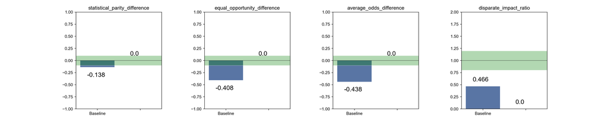

```python
plot_fair_metrics([0, 0, 0, 0], '')
plt.show()
```

As discussed above, all four fairness metrics define the baseline model as unfairly benefitting white defendants. The green bar represents the range of fair values, while the blue bars are the actual metric values for the baseline model. We can see that the margin of unfairness is smallest for statistical parity difference, as the value is only 0.038 outside of the -0.1 to 0.1 range of fairness. However, for the other three metrics, the value is significantly below the margin of fairness.

# Pre-Processing

Pre-processing refers to mitigating bias within the training data. For our pre-processing approach we are using AIF360’s Reweighing algorithm. The reweighing approach “assigns different weights to the examples based upon their categories of protected attribute and outcome such that bias is removed from the training dataset” ( [Mahmoudian](https://towardsdatascience.com/reweighing-the-adult-dataset-to-make-it-discrimination-free-44668c9379e8)).

## Reweighing

```python
acc_REW = accuracy_score(y_test, y_pred_REW)
print(f'[Reweighing] The test accuracy of the algorithm is: {acc_REW: .2%}')
```

```
## [Reweighing] The test accuracy of the algorithm is:  60.96%
```

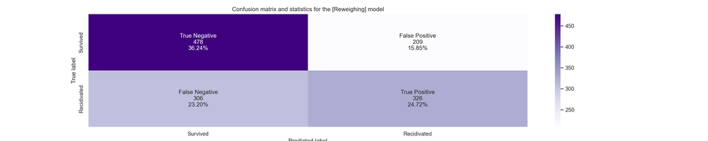

```python
cf_matrix = confusion_matrix(y_test, y_pred_REW)
make_confusion_matrix(cf_matrix, "[Reweighing]")
plt.show()
```

The highest percentage in this confusion matrix is for the percentage of true negatives, defendants who were predicted to not recidivate and actually did not, at 36.24%, 0.83% higher than the true negatives in the baseline model. This means that the reweighing model marginally improved the baseline model accuracy in predicting people who did not recidivate. However, the percentage of true positives, or those who were predicted to recidivate and did recidivate, is 24.72%, 1.13% lower than that of the baseline model. This means that the reweighing model slightly lowered the accuracy of the baseline model in predicting people who did recidivate. As a result, the overall reweighing model accuracy remains about the same as the baseline model accuracy. The false negative and false positive percentages, or the predictions that proved to be incorrect, are 23.20% and 15.85%, respectively. The re-weighing model increased the number of false negatives by 1.14% and decreased the number of false positives by 0.83%. We are most concerned about the false positives, which indicate defendants who are predicted to recidivate and do not actually recidivate. While there is a slight improvement in the percent of false positives, it is still relatively high at 15.85%, indicating that we should further precede with additional bias mitigation techniques.

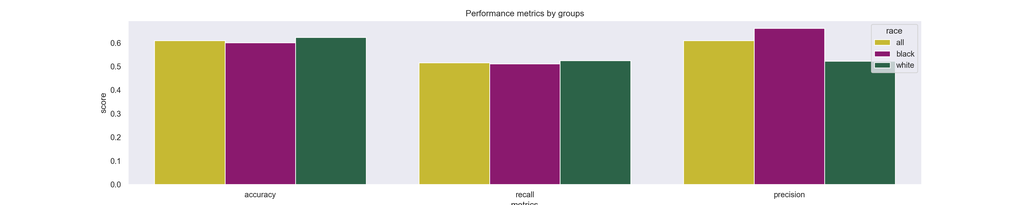

```python
metrics_per_group(y_test, y_pred_REW)
plt.show()
```

Like we saw in the metrics plot for the baseline model, the model accuracy for defendants of all races hovers around 61%, being slightly lower for Black defendants and slightly higher for white defendants. However, we can note that the gap between accuracy for Black and white defendants is smaller that it was with the baseline model (about a 3% gap rather than 4%).

We can see clear effects of the reweighing approach in the recall scores, which are now all very similar around 0.5. This is a marked improvement from the baseline model, where the model only correctly identified white defendants who recidivated 20% of the time. The reweighing model now correctly identifies defendants of any race who recidivate about half of the time. Notably, the reweighing also lowered the recall score for Black defendants.

Whereas with the baseline model all three precision scores were relatively similar, with the reweighing model we see the precision score for Black defendants is the highest. The models predictions for Black defendants who recidivate are correct about 66% of the time. In contrast, these predictions are correct for white defendents only 50% of the time, and correct for all defendants 60% of the time. The increase in precision for Black defendants shows the effects of the bias mitigation, as fewer Black people are being incorrectly predicted to recidivate.

### Statistical Parity Difference

```python
stat_par_diff_RW = statistical_parity_difference(y_test, y_pred_REW, prot_attr='race', pos_label = 0)

print(f'[Reweighing] The statistical parity difference is {stat_par_diff_RW: .2}')
```

```
## [Reweighing] The statistical parity difference is -0.015
```

This is a large improvement over our baseline model, which was -0.14. It still implies a slight benefit for white individuals, but it is in the range of -0.1 and 0.1.

### Equal Opportunity Difference

```python
eq_opp_diff_RW = equal_opportunity_difference(y_test, y_pred_REW, prot_attr='race', pos_label = 0)

print(f'[Reweighing] The equal opportunity difference is {eq_opp_diff_RW: .2}')
```

```
## [Reweighing] The equal opportunity difference is  0.015
```

This is also an improvement from the baseline, as it is now between -0.1 and 0.1. It also now implies a slight benefit for Black defendants.

### Average Odds Difference

```python
avg_odds_diff_RW = average_odds_difference(y_test, y_pred_REW, prot_attr='race', pos_label = 0)

print(f'[Reweighing] The average odds difference is {avg_odds_diff_RW: .2}')
```

```
## [Reweighing] The average odds difference is  0.014
```

### Disparate Impact Ratio

```python
disp_impact_ratio_RW = disparate_impact_ratio(y_test, y_pred_REW, prot_attr='race', priv_group = 1, pos_label = 0)

print(f'[Reweighing] The disparate impact ratio is {disp_impact_ratio_RW: .2}')
```

```
## [Reweighing] The disparate impact ratio is  0.98
```

The reweighing approach also improves the disparate impact ratio, bringing the value almost to 1, which conveys absolute fairness.

### Plot Fairness Metrics (Reweighing)

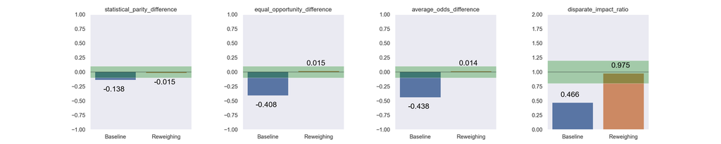

```python
plot_fair_metrics([stat_par_diff_RW, eq_opp_diff_RW, avg_odds_diff_RW, disp_impact_ratio_RW], 'Reweighing')
plt.show()
```

The orange bars in these graphs represent the new values of the fairness metrics after implementing the reweighing approach. Like we saw above, reweighing the data improved the fairness in all four of these metrics. All four values are now within the range of values considered fair. Statistical parity difference and disparate impact ratio still imply a slight benefit for white defendants, while equal opportunity difference and average odds difference now imply a slight benefit for Black defendants.

# In-Processing

In-processing mitigates bias in classifiers while building a model. The in-processing technique we use is the prejudice remover algorithm from AIF360. The prejudice remover is a method for reducing indirect prejudice (i.e. how the COMPAS algorithm is racially biased because it uses proxy variables for race). This approach implements two different regularizers, one to avoid overfitting and one to enforce fair classification ( [Kamishima et. al.](https://link.springer.com/content/pdf/10.1007/978-3-642-33486-3_3.pdf)). The prejudice remover regularizer works by minimizing the prejudice index, a mathematical equation for quantifying fairness defined by [Kamishima et. al](https://link.springer.com/content/pdf/10.1007/978-3-642-33486-3_3.pdf). This in turn enforces a classifier’s independence from sensitive information (like race).

```python
df_train = X_train.copy()
df_train["two_year_recid"] = y_train
df_train.rename(columns={6:'race'}, inplace=True)
df_train = df_train.reset_index(drop=True)

df_test = X_test.copy()
df_test["two_year_recid"] = y_test
df_test = df_test.reset_index(drop=True)
df_test.rename(columns={6:'race'}, inplace=True)
```

```python
train_BLD = BinaryLabelDataset(favorable_label='0',
                                unfavorable_label='1',
                                df=df_train,
                                label_names=['two_year_recid'],
                                protected_attribute_names=['race'])

test_BLD = BinaryLabelDataset(favorable_label='0',
                                unfavorable_label='1',
                                df=df_test,
                                label_names=['two_year_recid'],
                                protected_attribute_names=['race'])
```

## Prejudice Remover

```python
from aif360.algorithms.inprocessing import PrejudiceRemover

prej = PrejudiceRemover(eta = 1.0, sensitive_attr='race', class_attr='two_year_recid')
prej.fit(train_BLD)
```

```
## <aif360.algorithms.inprocessing.prejudice_remover.PrejudiceRemover object at 0x12aa41190>
```

```python
y_pred_PREJ = prej.predict(test_BLD)
y_pred_PREJ = y_pred_PREJ.labels.flatten()
```

```python
acc_PREJ = accuracy_score(y_test, y_pred_PREJ)
print(f'[Prejudice Remover] The test accuracy of the algorithm is: {acc_PREJ: .2%}')
```

```
## [Prejudice Remover] The test accuracy of the algorithm is:  38.21%
```

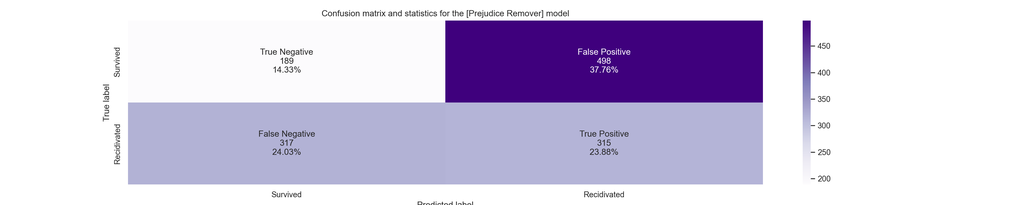

```python
cf_matrix = confusion_matrix(y_test, y_pred_PREJ)
make_confusion_matrix(cf_matrix, "[Prejudice Remover]")
plt.show()
```

The highest percentage in this confusion matrix is for false positives, defendants who the model predicted to recidivate and actually did not, at 37.76%. This false positive percentage concerns us because we do not want defendants who do not recidivate to have unfairly long sentences due to their (incorrectly) predicted recidivism. The number of true positives, defendants who the model predicted to recidivate and actually recidivated, is lower at 23.88%. The percentage of false negatives is lower, whereas the true negative is lowest at 14.33%. This indicates that the model does not do a good job in predicting the defendents who don’t recidivate. It is very likely that it will incorrectly predict that someone will recidivate.

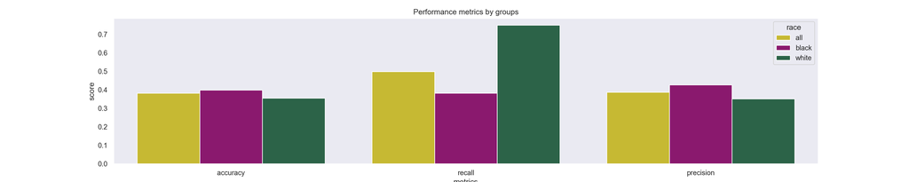

```python
metrics_per_group(y_test, y_pred_PREJ)
plt.show()
```

After the prejudice remover, the accuracy of the model is fairly similar across the board of races, but the model’s accuracy is only 38.21%, which is much lower than the baseline and reweighing models. This accuracy score means that the model makes accurate predictions only 38% of the time.

In terms of recall, the score for white defendants is very high at 0.7, meaning that the model correctly identifies white defendants who recidivate about 70% of the time. This number is about 50% for all defendants, but only 40% for Black defendants. Just as we saw a low recall score for white defendants in the baseline model, now we see the same for Black defendants in the prejudice remover model. This means that the model frequently predicts Black defendants to not recidivate (the more favorable outcome) when they actually do.

Finally, the precision score has lowered from about 0.6 for the baseline model to about 0.4 for all defendants, 0.45 for Black defendants, and 0.3 for white defendants. This means that the model’s predictions of a defendant who recidivates are accurate about 40% of the time, a number which is slightly higher for Black defendants and slightly lower for white defendants.

### Statistical Parity Difference

```python
stat_par_diff_PREJ = statistical_parity_difference(y_test, y_pred_PREJ, prot_attr='race', pos_label = 0)

print(f'[Prejudice Remover] The statistical parity difference is {stat_par_diff_PREJ: .2}')
```

```
## [Prejudice Remover] The statistical parity difference is  0.37
```

Compared to the baseline model, the predjudice remover is highly in favor of the unprivileged group, Black defendants, because its value is greater than 0. The value of 0.367 is much higher than 0, the value of fairness.

### Equal Opportunity Difference

```python
eq_opp_diff_PREJ = equal_opportunity_difference(y_test, y_pred_PREJ, prot_attr='race', pos_label = 0)

print(f'[Prejudice Remover] The equal opportunity difference is {eq_opp_diff_PREJ: .2}')
```

```
## [Prejudice Remover] The equal opportunity difference is  0.32
```

Compared to the baseline model, the predjudice remover is highly in favor of Black defendants because its value is greater than 0. The value of 0.321 is much higher than 0, the value of fairness.

### Average Odds Difference

```python
avg_odds_diff_PREJ = average_odds_difference(y_test, y_pred_PREJ, prot_attr='race', pos_label = 0)

print(f'[Prejudice Remover] The average odds difference is {avg_odds_diff_PREJ: .2}')
```

```
## [Prejudice Remover] The average odds difference is  0.34
```

Compared to the baseline model, the predjudice remover is highly in favor of Black defendants, because its value is greater than 0.

### Disparate Impact Ratio

```python
disp_impact_ratio_PREJ = disparate_impact_ratio(y_test, y_pred_PREJ, prot_attr='race', priv_group = 1, pos_label = 0)

print(f'[Prejudice Remover] The disparate impact ratio is {disp_impact_ratio_PREJ: .2}')
```

```
## [Prejudice Remover] The disparate impact ratio is  3.3
```

The value of 3.3 indicates that the model is highly in favor of Black defendents, as it is much greater than 1. This is a hugely different from the baseline model which favors white defendants.

### Plot Fairness Metrics (Prejudice Remover)

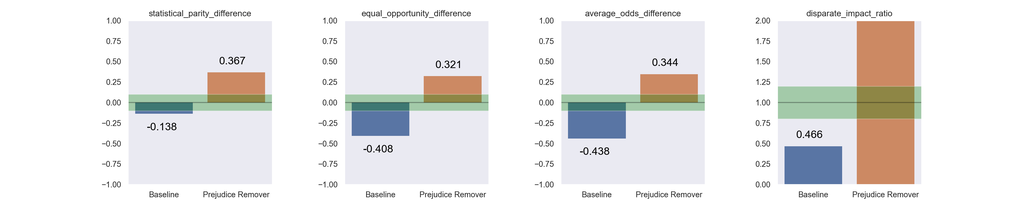

```python
plot_fair_metrics([stat_par_diff_PREJ, eq_opp_diff_PREJ, avg_odds_diff_PREJ, disp_impact_ratio_PREJ], 'Prejudice Remover')
plt.show()
```

Like the model performance metrics suggested, the prejudice remover approach resulted in an increased benefit for Black defendants. As the orange bars on these plots show, the values of the fairness metrics have reversed from their baseline values. Now all four metrics suggest an unfair advantage for Black defendants. Thus, this approach removed the model’s prejudice against Black people, but it did not result in a “fair” model.

# Post-Processing

Our last approach, post-processing bias mitigation, is used after training a model. Post-processing algorithms equalize the outcomes (i.e., predicted classification values) to mitigate bias instead of adjusting the classifier or the training data( [Baxter](https://www.infoworld.com/article/3630450/what-is-ai-bias-mitigation-and-how-can-it-improve-ai-fairness.html)). We use calibrated equalized odds, which “optimizes over calibrated classifier score outputs to find probabilities with which to change output labels with an equalized odds objective” ( [AIF360](https://aif360.readthedocs.io/en/stable/modules/generated/aif360.algorithms.postprocessing.CalibratedEqOddsPostprocessing.html#aif360.algorithms.postprocessing.CalibratedEqOddsPostprocessing)). An equalized odds objective constrains classification algorithms such that no error type (false-positive or false-negative) disproportionately affects any population subgroup; both groups, in our case both white and Black defendants, should have the same false-positive and false-negative rates. Through the calibrated equalized odds method, we want to decrease bias while also maintaining calibration ( [Pleiss et. al.](https://arxiv.org/pdf/1709.02012.pdf)). [Calibration](https://medium.com/analytics-vidhya/calibration-in-machine-learning-e7972ac93555) refers to improving a model so that the distribution of predicted outcomes is similar to the distribution of observed probability in the training data.

## Calibrated Equalized Odds

```python
acc_CEO = accuracy_score(y_test, y_pred_CEO)
print(f'[Calibrated Equalized Odds] The test accuracy of the algorithm is: {acc_CEO: .2%}')
```

```
## [Calibrated Equalized Odds] The test accuracy of the algorithm is:  53.15%
```

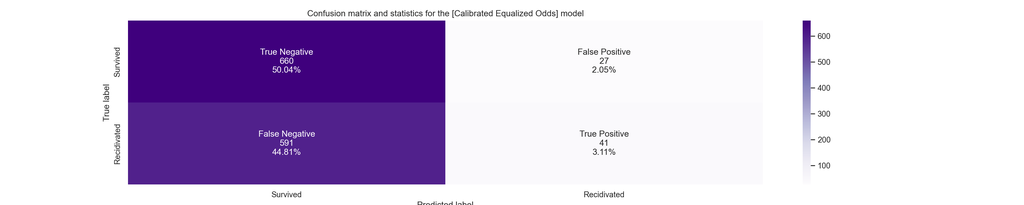

```python
cf_matrix = confusion_matrix(y_test, y_pred_CEO)
make_confusion_matrix(cf_matrix, "[Calibrated Equalized Odds]")
plt.show()
```

The highest percentage in this confusion matrix is for true negatives, defendants who the model predicted to not recidivate and actually did not, at 50.04%. The number of true positives, defendants who the model predicted to recidivate and actually recidivated, is much lower at 3.11%. The percentage of false negatives is somewhat high compared to the baseline model, whereas the percentage of false positives is very low at 2.05%. This indicates that the model does a good job in predicting the defendents who don’t recidivate. It is very unlikely that it will incorrectly predict that someone will recidivate. Though the accuracy score for the model is 0.53, lower than the baseline, this model is much better at identifying true negatives.

### Statistical Parity Difference

```python
stat_par_diff_CEO = statistical_parity_difference(y_test, y_pred_CEO, prot_attr='race', pos_label = 0)

print(f'[Calibrated Equalized Odds] The statistical parity difference is {stat_par_diff_CEO: .2}')
```

```
## [Calibrated Equalized Odds] The statistical parity difference is  0.13
```

At the value of 0.134, the statistical parity difference is now positive and slightly in favor of Black defendants. However, it is just outside the bounds of fairness.

### Equal Opportunity Difference

```python
eq_opp_diff_CEO = equal_opportunity_difference(y_test, y_pred_CEO, prot_attr='race', pos_label = 0)

print(f'[Calibrated Equalized Odds] The equal opportunity difference is {eq_opp_diff_CEO: .2}')
```

```
## [Calibrated Equalized Odds] The equal opportunity difference is  0.088
```

There has been a significant change from -0.408 to 0.088, showing that now the value is within the bounds of “fair” (-0.1 to 0.1). Additionally, since the value is positive, it implies a slight benefit for Black defendants.

### Average Odds Difference

```python
avg_odds_diff_CEO = average_odds_difference(y_test, y_pred_CEO, prot_attr='race', pos_label = 0)

print(f'[Calibrated Equalized Odds] The average odds difference is {avg_odds_diff_CEO: .2}')
```

```
## [Calibrated Equalized Odds] The average odds difference is  0.15
```

The baseline model with the average odds difference was -0.438 and now it is 0.15, which indicates slight unfairness (as it is above 0.1) and the model being in favor of Black defendants.

### Disparate Impact Ratio

```python
disp_impact_ratio_CEO = disparate_impact_ratio(y_test, y_pred_CEO, prot_attr='race', priv_group = 1, pos_label = 0)

print(f'[Calibrated Equalized Odds] The disparate impact ratio is {disp_impact_ratio_CEO: .2}')
```

```
## [Calibrated Equalized Odds] The disparate impact ratio is  1.2
```

The baseline value was 0.466, which is significantly below the range of “fair” which begins at 0.8. Now at a value of 1.15 it is above 1, conveying fairness and a benefit of Black defendants.

### Plot Fairness Metrics (Calibrated Equalized Odds)

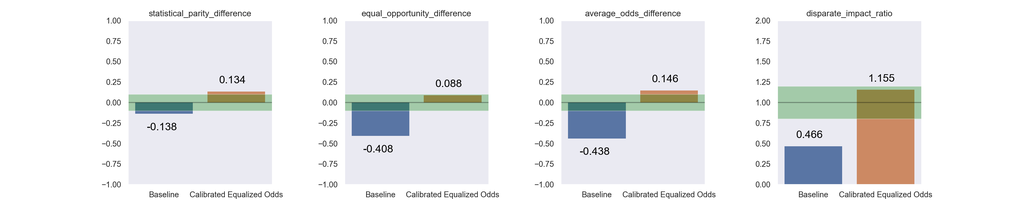

```python
plot_fair_metrics([stat_par_diff_CEO, eq_opp_diff_CEO, avg_odds_diff_CEO, disp_impact_ratio_CEO], 'Calibrated Equalized Odds')
plt.show()
```

As we can see from the orange bars, the calibrated equalized odds approach results in all four metrics now suggesting a benefit for the originally unprivileged group, Black defendants. Though the values for statistical parity difference and average odds difference are slightly above the range of what is considered fair, the margin is much smaller than the original margin between the value and the range of fairness (as indicated by the blue bars). Thus, the calibrated equalized odds approach successfully counteracts the bias against Black defendants and results in a mostly fair model.